# NBA Regular Season Win Prediction

```r
require(tidyr)
require(ggplot2)
require(dplyr)
require(randomForest)
require(gbm)
```

# Background

In the NBA, the best regular season record doesn’t [necessarily promise a championship](https://en.wikipedia.org/wiki/List_of_NBA_teams_by_single_season_win_percentage), but it’s still very important since it determines whether you advance and the seeding during the playoffs. Among the top 8 teams from each division (East and West), the team with the best record plays the team with the worst one. Therefore, teams with a better record (i.e., more regular season wins) are rewarded with a (*usually*) “easier” path to the championship. Beyond the obvious interest to basketball teams, betting markets offer the ability to bet the over/under on the number of wins each team will get in a regular season. For instance, will the Golden State Warriors win more or less than 67 games this season?

I was interested in investigating the following questions:

1. Can a model accurately predict the number of regular season wins a team?
2. What team statistics are most important for predicting number of wins?
3. What is the best model to use between bagging, random forests, and boosting?

# Dataset

[Basketball-reference.com](https://www.basketball-reference.com/) is a tremendous resource for all types of basketball statistics. My dataset consisted of regular season records for teams in the National Basketball Association (NBA) for the 2013-14 through 2017-18 regular season. There are 5 seasons and 30 teams, so there are 150 rows consisting of each team’s record in each season. In addition, I included various [“Team Per Game Stats”](https://www.basketball-reference.com/leagues/NBA_2018.html#team-stats-per_game::none) and [“Opponent Per Game Stats”](https://www.basketball-reference.com/leagues/NBA_2018.html#opponent-stats-per_game::none). For this analysis, I manually selected 16 variables: 3-point shot percentage, 2-point shot percentage, field goal percentage (i.e., both 2- and 3-point shots), free throw percentage, offensive rebounds, defensive rebounds, assists, steals, blocks, turnovers, personal fouls, points scored, points allowed, offensive rating, defensive rating, and pace of play.

# Exploratory Analysis

First, I wanted to check all of the team names. I noticed all of the team names had 5 instances (as expected give the 5 seasons), except the Charlotte Bobcats and Charlotte Hornets that had only 1 and 4 instances, respectively. This is because the [Charlotte Bobcats rebranded as the Charlotte Hornets after the 2013-14 season](https://en.wikipedia.org/wiki/Charlotte_Hornets). Therefore, I consolidated all instances of the team name as the “Charlotte Hornets”.

```r
table(merged_df$Team)
```

```
##
##          Atlanta Hawks         Boston Celtics          Brooklyn Nets
##                      5                      5                      5
##      Charlotte Bobcats      Charlotte Hornets          Chicago Bulls
##                      1                      4                      5
##    Cleveland Cavaliers       Dallas Mavericks         Denver Nuggets
##                      5                      5                      5
##        Detroit Pistons  Golden State Warriors        Houston Rockets
##                      5                      5                      5
##         Indiana Pacers   Los Angeles Clippers     Los Angeles Lakers
##                      5                      5                      5
##      Memphis Grizzlies             Miami Heat        Milwaukee Bucks
##                      5                      5                      5
## Minnesota Timberwolves   New Orleans Pelicans        New York Knicks
##                      5                      5                      5
##  Oklahoma City Thunder          Orlando Magic     Philadelphia 76ers
##                      5                      5                      5
##           Phoenix Suns Portland Trail Blazers       Sacramento Kings
##                      5                      5                      5
##      San Antonio Spurs        Toronto Raptors              Utah Jazz
##                      5                      5                      5
##     Washington Wizards
##                      5
```

```r
merged_df$Team[which(merged_df$Team=="Charlotte Bobcats")] <- "Charlotte Hornets"
```

During this period, the Golden State Warriors won the most games with 286 total wins, while the Philadelphia 76ers won the least with only 90 wins. This was a very interesting time for both these teams, as the Golden State Warriors had broken records for winning and the 76ers had controversially set records for losing - *the motivation for which is a discussion for another day*.

```r
aggregate(W ~ Team, merged_df, sum) %>% arrange(desc(W)) %>% head
```

|  | Team | W |
| --- | --- | --- |
| 1 | Golden State Warriors | 286 |
| 2 | San Antonio Spurs | 270 |
| 3 | Los Angeles Clippers | 232 |
| 4 | Houston Rockets | 231 |
| 5 | Toronto Raptors | 228 |
| 6 | Oklahoma City Thunder | 226 |

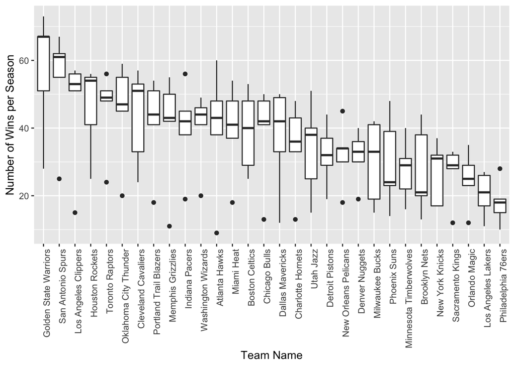

```r
merged_df %>%
  mutate(Team = as.factor(Team)) %>%
  ggplot(aes(x = reorder(Team, -W, mean), y=W)) + geom_boxplot() + labs(y = "Number of Wins per Season", x = "Team Name") + theme(axis.text.x = element_text(angle = 90, hjust = 1))
```

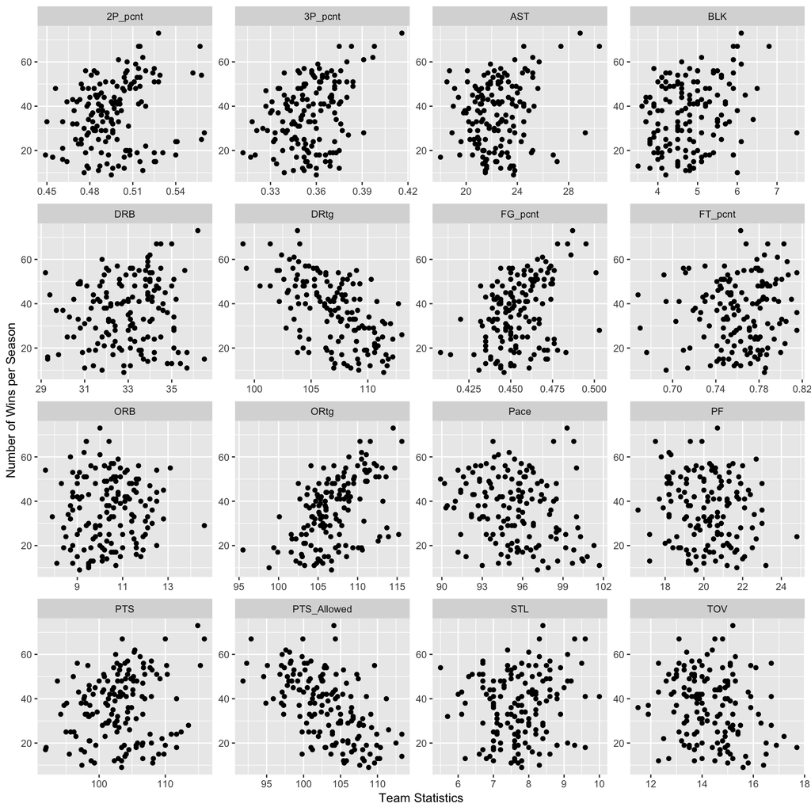

```r
names(merged_df)[c(3,4,5,6)] <- c("FG_pcnt", "3P_pcnt", "2P_pcnt", "FT_pcnt")

merged_df %>%
  select(-Team, -Season) %>%
  gather(-W, key = "some_var_name", value = "some_value_name") %>%
  ggplot(aes(x = some_value_name, y = W)) +
    geom_point() +
    facet_wrap(~ some_var_name, scales = "free", ncol=4) +
    labs(y = "Number of Wins per Season", x= "Team Statistics")
```

# Machine Learning Prediction of Wins

## Training & Testing Sets

```r
final_df <- merged_df %>% select(-Team, -Season)

names(final_df) <- make.names(names(final_df))

set.seed(1)
train = sample(1:nrow(final_df), floor(nrow(final_df)*0.7))
#Training Set Wins
summary(final_df[train,"W"])
```

```
##    Min. 1st Qu.  Median    Mean 3rd Qu.    Max.
##    9.00   23.00   37.00   35.72   46.00   73.00
```

```r
#Testing Set Wins
summary(final_df[-train,"W"])
```

```
##    Min. 1st Qu.  Median    Mean 3rd Qu.    Max.
##   10.00   25.00   41.00   37.73   50.00   62.00
```

## Bagging

*Bagging is a technique, where m samples are taken at random with replacement from a dataset and a tree fit to each random sample. Depending on the type of outcome variable - continuous or binary - the average or mode of the predictions of the m models becomes the final prediction.* For bagging, the 5 most important variables according to %IncMSE were: points allowed (+24%), offensive rating (+20%), defensive rating (+14%), 3P% (+8%), and points scored (+8%).

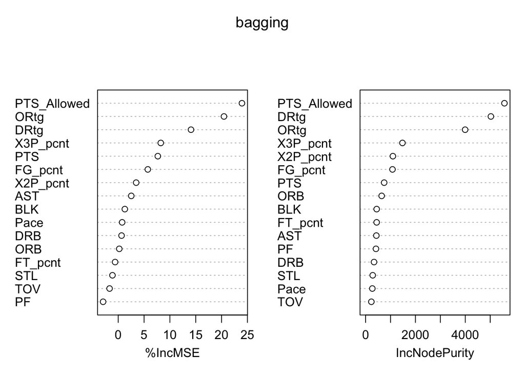

```r
bagging=randomForest(W~.,data=final_df,subset=train,mtry=(ncol(final_df)-1),importance=TRUE)

yhat.bag = predict(bagging,newdata=final_df[-train,])

varImpPlot(bagging)
```

## Random Forests

*Random forests are a special case of bagging, where only a random sample M of all available predictors (p) is available at each split in the tree. This aspect avoids overfitting by preventing any single predictor from constantly dominating all the trees. As a rule of thumb, the number of predictors at each split is √p.*

In the random forest model, the 5 most important variables according to %IncMSE if removed were: points allowed (+20%), offensive rating (+16%), defensive rating (+13%), field goal percentage (+7%) and 3-point percentage (+7%)

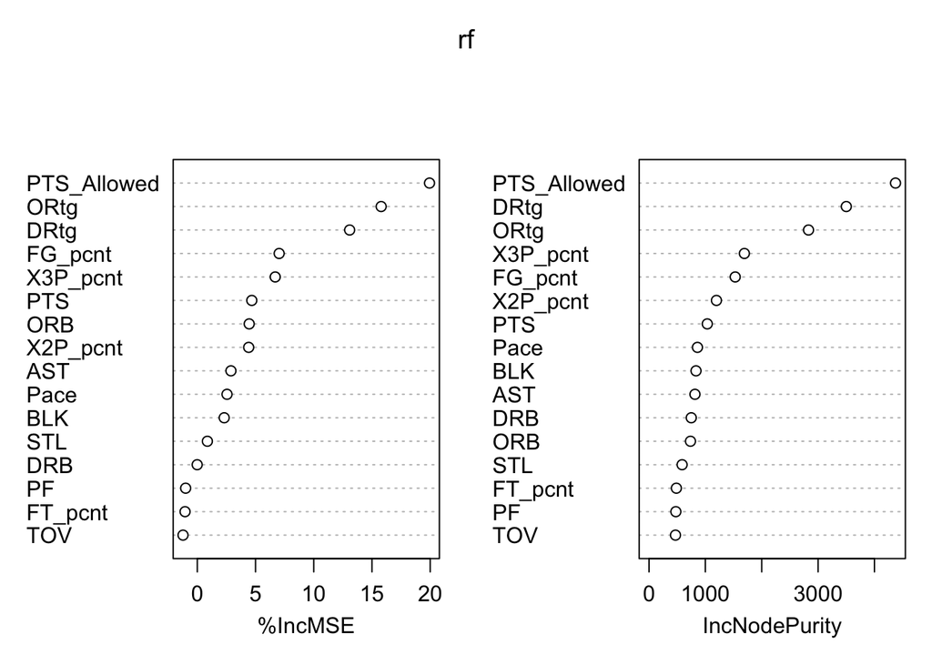

```r
rf=randomForest(W~.,data=final_df,subset=train,mtry=sqrt(ncol(final_df)-1),importance=TRUE,ntree=500)

yhat.rf = predict(rf, newdata=final_df[-train,])

varImpPlot(rf)
```

## Boosting

*Boosting is a technique where an ensemble of trees is built sequentially, such that each subsequent tree is modeled to minimize the residual error terms from the previous trees. It relies on the idea that each individual tree will be a weak learner but combined all of the trees together become a strong learner that is less prone to overfitting. I selected a shrinkage parameter ($\lambda$) of 0.1, and set a maximum depth (d) of 4 layers per tree.* In the boosting model, the 5 most important variables according to relative influence were: defensive rating (20), points allowed (16), offensive rating (14), 3-point percentage (9), and 2-point percentage (5)

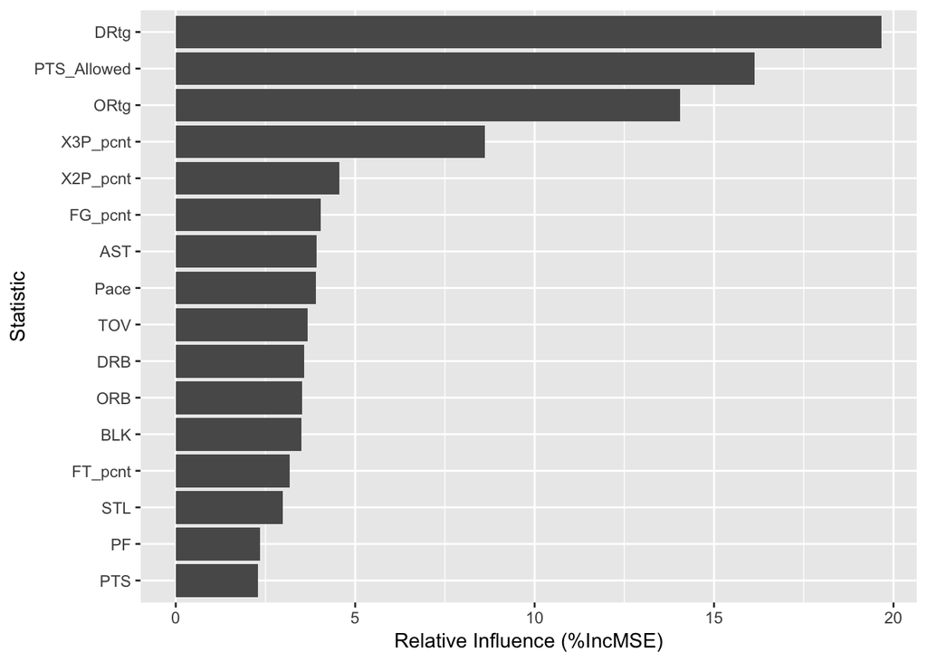

```r
boost=gbm(W~.,data=final_df[train,], distribution="gaussian", n.trees=5000, interaction.depth=4)

yhat.boost=predict(boost,newdata=final_df[-train,], n.trees=5000)

boostImp<-summary(boost, plotit = FALSE)
boostImp %>% ggplot(aes(x=reorder(var, rel.inf), y=rel.inf)) + geom_bar(stat = 'identity') + coord_flip() +
  labs(x="Statistic", y="Relative Influence (%IncMSE)")
```

## Comparison

The MSE for number of wins was similar across all the algorithms:

1. Bagging (MSE = 136)
2. Random Forest (MSE = 137)
3. Boosting (MSE = 136)

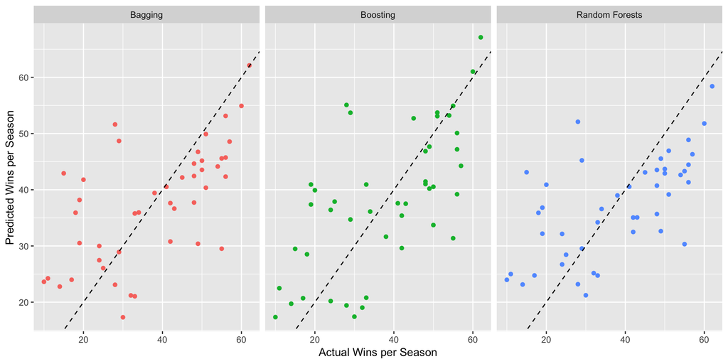

```r
comp <- data.frame(Prediction = integer(135),
                   Actual = integer(135),
                   Method = character(135))
comp$Actual <- rep(test_set ,3)
comp$Prediction <- c(yhat.bag, yhat.rf, yhat.boost)
comp$Method <- c(rep("Bagging", length(yhat.bag)), rep("Random Forests", length(yhat.rf)), rep("Boosting", length(yhat.boost)))

comp %>%
ggplot(aes(x=Actual, y=Prediction, color=Method)) + geom_point() + geom_abline(slope=1, intercept = 0, lty=2) + facet_wrap(Method~.) + labs(x="Actual Wins per Season", y="Predicted Wins per Season") + theme(legend.position="none")
```

# Conclusion

# Next Steps

1. Incorporate more variables into the models. This may require some feature selection methods to avoid a problem with high dimensionality.
2. Machine learning may work better if I use a larger sample size (i.e., data from more seasons). This is particularly important if I follow step #1 to avoid problems with high dimensionality.
3. One of my motivating applications for this analysis was predicting the number of wins for betting markets. It would be interesting to investigate whether regular season statistics from the previous season can predict the win record in the next season.